# Creating Web Application with RShiny

Eric Goh

2020 M10 4

SHiny allows us to create Web Applications. To use R SHiny:

install.apackages("shiny");

[figure not shown]

CReate two R scripts, save as ui.R and server,R. both ui.R and server.R must be in same folder. Type everything out, you will understand what it means.

ui.R

```markdown
library(shiny)

shinyUI(pageWithSidebar(

  headerPanel("Hello Shiny"),

  sidebarPanel(

    sliderInput("obs",
                "Number of Observations",
                min = 1,
                max = 1000,
                value = 500)

  ),

  mainPanel(
    plotOutput("distPlot")
  )


))
```

server.R

[figure not shown]

[figure not shown]

```markdown
library(shiny)

shinyServer(function(input, output) {


  output$distPlot <- renderPlot({

    dist <- rnorm(input$obs);
    hist(dist);
  })
})
```

# Shiny Web App

This is how the Shiny Web App works...

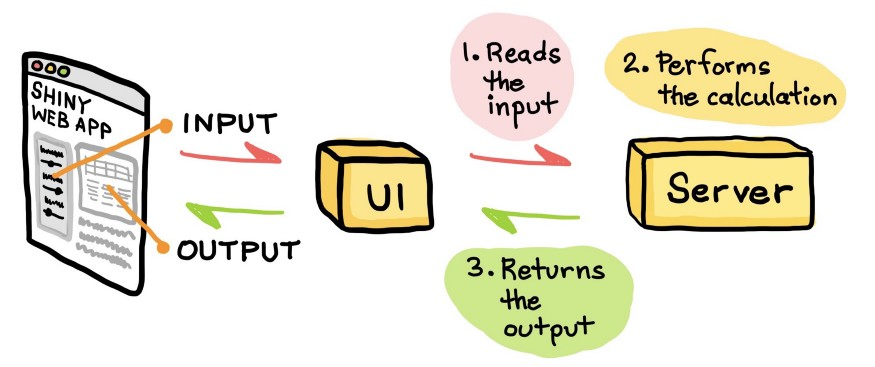

Extracted: https://towardsdatascience.com/build-your-first-shiny-web-app-in-r-72f9538f9868

Look at txt1, txt2, and input txt1, input txt2, there are similarities in the ui.R and server.R codes. plotOutput("distPlot") and output$distPlot.

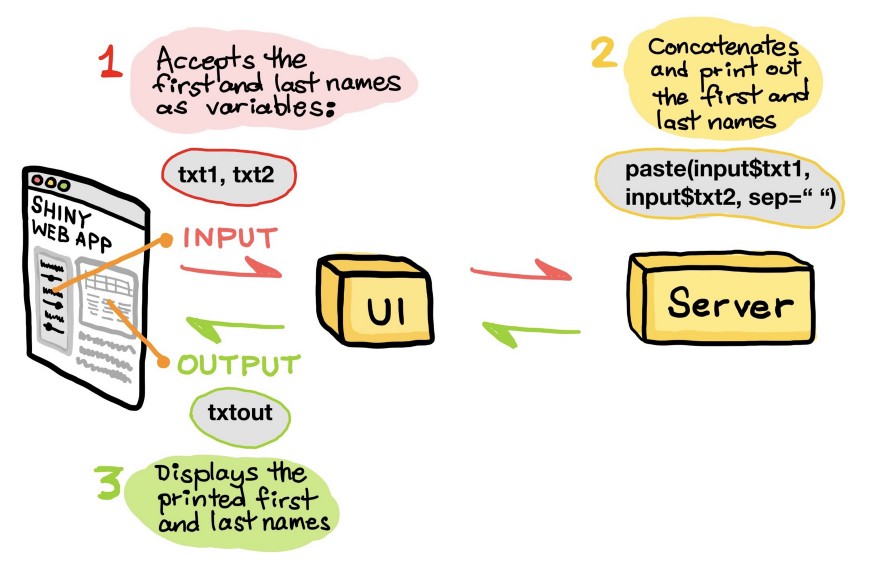

Extracted: https://towardsdatascience.com/build-your-first-shiny-web-app-in-r-72f9538f9868

# Reactive Expression

A reactive expression is an R expression that uses widget input and returns a value, the reactive expression will update this value whenever the original widget changes. Ractive expressions are lazy and cached.

Extracted https://campus.datacamp.com/courses/building-web-applications-with-shiny-in-r/reactive-programming-3?ex=3

# Tooling Up

I add in more sleect input, numeric input, radiobuttons, tabPanels...

ui.R

```markdown
library(shiny)

shinyUI(pageWithSidebar(

  headerPanel("Hello Shiny"),

  sidebarPanel(

    selectInput("dataset", "Choose a dataset:",
                choices = c("fg", "dfg", "gdh")),

    numericInput("obs2", "Number of observations to view:", 10),

    sliderInput("obs",
                "Number of Observations",
                min = 1,
                max = 1000,
                value = 500),

    radioButtons("dist", "Distribution Type",
                 list("Normal" = "norm",
                      "Uniform" = "unif",
                      "Log-normal" = "lnorm",
                      "Exponentil" = "exp"
                      ))

  ),

  mainPanel(

    tabsetPanel (
      tabPanel("Plot", plotOutput("distPlot")),
      tabPanel("Summary", verbatimTextOutput("Summary")),
      tabPanel("Table", tableOutput("table")),
      tabPanel("DatatTable", dataTableOutput("myTable"))
    )
  )


))
```

server.R

[figure not shown]

```markdown
library(shiny)
library(datasets)

shinyServer(function(input, output) {


  output$distPlot <- renderPlot({

    dist <- rnorm(input$obs);
    hist(dist);
  })

  output$summary <- renderPrint({

    summary(iris);

  })

  output$table <- renderTable({
    data.frame(x = iris)
  })

  output$myTable <- renderDataTable({
    iris
  }, , options = list(aLengthMenu = c(5, 30, 50), iDisplayLength = 5))

})
```

# COVID 19 Project

After learning about R shiny basics, we can create COVID 19 dashboards. You need to wait for the data to be downloaded.

ui.R

```markdown
library(shiny)

shinyUI(pageWithSidebar(

  headerPanel("COVID 19"),

  sidebarPanel(

    selectInput("Countries", "Countries: ", selected = "Singapore", choices = c("Afghanistan", "Albania", "Algeria", "Andorra", "Angola", "Anguilla", "Antigua_and_Barbuda", "Argentina", "Armenia", "Aruba", "Australia", "Austria", "Azerbaijan", "Bahamas", "Bahrain", "Bangladesh", "Barbados", "Belarus", "Belgium", "Belize", "Benin", "Bermuda", "Bhutan", "Bolivia", "Bonaire, Saint Eustatius and Saba", "Bosnia_and_Herzegovina", "Botswana", "Brazil", "British_Virgin_Islands", "Brunei_Darussalam", "Bulgaria", "Burkina_Faso", "Burundi", "Cambodia", "Cameroon", "Canada", "Cape_Verde", "Cases_on_an_international_conveyance_Japan", "Cayman_Islands", "Central_African_Republic", "Chad", "Chile", "China", "Colombia", "Congo", "Costa_Rica", "Cote_dlvoire", "Croatia", "Cuba", "Curaçao", "Cyprus", "Czechia", "Democratic_Republic_of_the_Congo", "Denmark", "Djibouti", "Dominica", "Dominican_Republic", "Ecuador", "Egypt", "El_Salvador", "Equatorial_Guinea", "Eritrea", "Estonia", "Eswatini", "Ethiopia", "Falkland_Islands_(Malvinas)", "Faroe_Islands", "Fiji", "Finland", "France", "French_Polynesia", "Gabon", "Gambia", "Georgia", "Germany", "Ghana", "Gibraltar", "Greece", "Greenland", "Grenada", "Guam", "Guatemala", "Guernsey", "Guinea", "Guinea_Bissau", "Guyana", "Haiti", "Holy_See", "Honduras", "Hungary", "Iceland", "India", "Indonesia", "Iran", "Iraq", "Ireland", "Isle_of_Man", "Israel", "Italy", "Jamaica", "Japan", "Jersey", "Jordan", "Kazakhstan", "Kenya", "Kosovo", "Kuwait", "Kyrgyzstan", "Laos", "Latvia", "Lebanon", "Liberia", "Libya", "Liechtenstein", "Lithuania", "Luxembourg", "Madagascar", "Malawi", "Malaysia", "Maldives", "Mali", "Malta", "Mauritania", "Mauritius", "Mexico", "Moldova", "Monaco", "Mongolia", "Montenegro", "Montserrat", "Morocco", "Mozambique", "Myanmar", "Namibia", "Nepal", "Netherlands", "New_Caledonia", "New_Zealand", "Nicaragua", "Niger", "Nigeria", "North_Macedonia", "Northern_Mariana_Islands", "Norway", "Oman", "Pakistan", "Palestine", "Panama", "Papua_New_Guinea", "Paraguay", "Peru", "Philippines", "Poland", "Portugal", "Puerto_Rico", "Qatar", "Romania", "Russia", "Rwanda", "Saint_Kitts_and_Nevis", "Saint_Lucia",  "Saint_Vincent_and_the_Grenadines", "San_Marino", "Sao_Tome_and_Principe", "Saudi_Arabia", "Senegal", "Serbia", "Seychelles", "Sierra_Leone", "Singapore", "Sint_Maarten", "Slovakia", "Slovenia", "Somalia", "South_Africa", "South_Korea", "South_Sudan", "Spain", "Sri_Lanka", "Sudan", "Suriname", "Sweden", "Switzerland", "Syria", "Taiwan", "Thailand", "Timor_Leste", "Togo", "Trinidad_and_Tobago", "Tunisia", "Turkey", "Turks_and_Caicos_islands", "Uganda", "Ukraine", "United_Arab_Emirates",  "United_Kingdom", "United_Republic_of_Tanzania", "United_States_of_America", "United_States_Virgin_Islands", "Uruguay", "Uzbekistan", "Venezuela", "Vietnam", "Yemen", "Zambia", "Zimbabwe"))

  ),

  mainPanel(

    tabsetPanel (
      tabPanel("Cases", plotOutput("distPlot")),
      tabPanel("Death", plotOutput("distPlot2")),
      tabPanel("Table", tableOutput("table"))
    )
  )


))
```

server.R

[figure not shown]

```markdown
library(shiny)
library(datasets)

data <- read.csv("https://opendata.ecdc.europa.eu/covid19/casedistribution/csv", na.strings = "", fileEncoding = "UTF-8-BOM")
print(data);

shinyServer(function(input, output) {

  newData <- reactive({data[which(data$countriesAndTerritories==input$Countries), ]});

  output$distPlot <- renderPlot({

    #newData <- data[which(data$countriesAndTerritories=="Singapore"), ];
    SepData <- newData()[which(newData()$month==9), ];

    plot(SepData$day, SepData$cases, type="l");


  })

  output$distPlot2 <- renderPlot({

    #newData <- data[which(data$countriesAndTerritories=="Singapore"), ];
    SepData <- newData()[which(newData()$month==9), ];

    plot(SepData$day, SepData$death, type="l");


  })

  output$table <- renderTable({
    newData()
  })

})
```

If you want to know more about COVID 19 dashboards

https://github.com/gohminghui88/covid

https://gohminghui88.shinyapps.io/COVID19/

[figure not shown]